# Data visualisation

### Exercise 3.8.2

What parameters to `geom_jitter()` control the amount of jittering?

From the [`geom_jitter()`](https://ggplot2.tidyverse.org/reference/geom_jitter.html) documentation, there are two arguments to jitter:

- `width` controls the amount of horizontal displacement, and
- `height` controls the amount of vertical displacement.

The defaults values of `width` and `height` will introduce noise in both directions. Here is what the plot looks like with the default values of `height` and `width`.

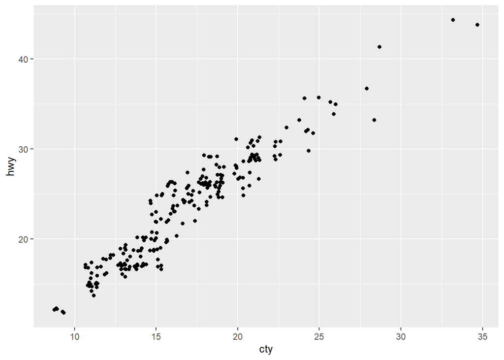

```r
ggplot(data = mpg, mapping = aes(x = cty, y = hwy)) +
  geom_point(position = position_jitter())
```

However, we can change these parameters. Here are few a examples to understand how these parameters affect the amount of jittering. When`width = 0` there is no horizontal jitter.

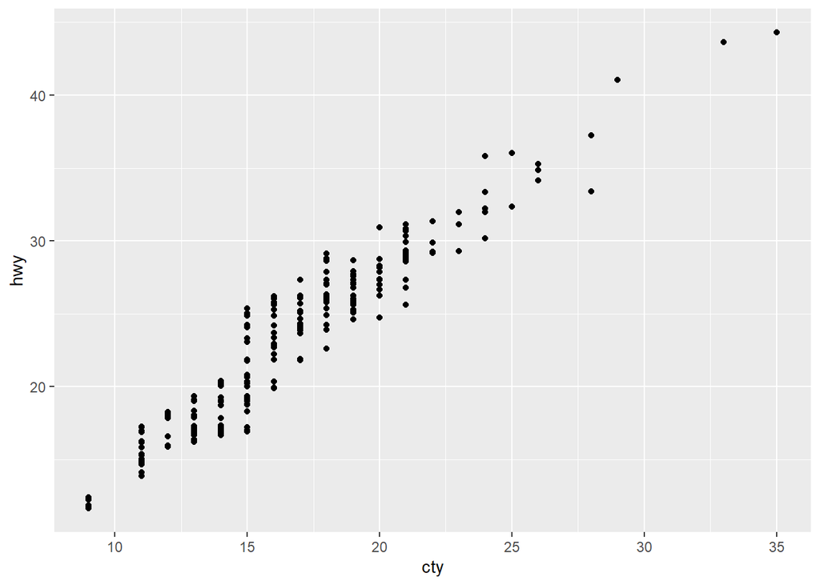

```r
ggplot(data = mpg, mapping = aes(x = cty, y = hwy)) +
  geom_jitter(width = 0)
```

When `width = 20`, there is too much horizontal jitter.

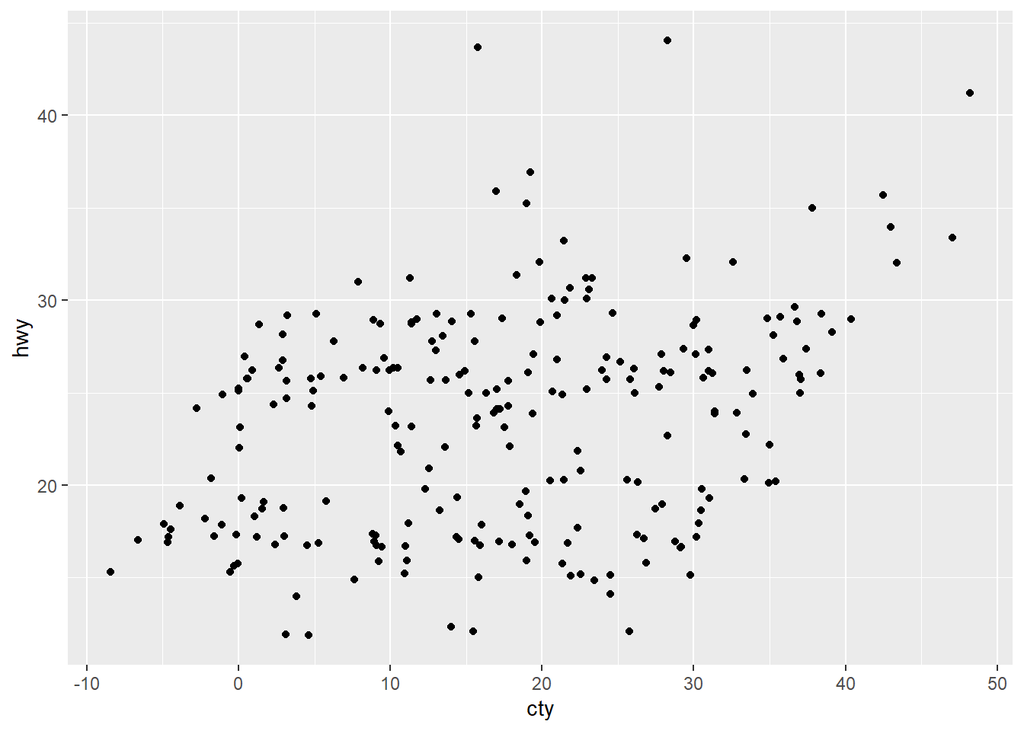

```r
ggplot(data = mpg, mapping = aes(x = cty, y = hwy)) +
  geom_jitter(width = 20)
```

When `height = 0`, there is no vertical jitter.

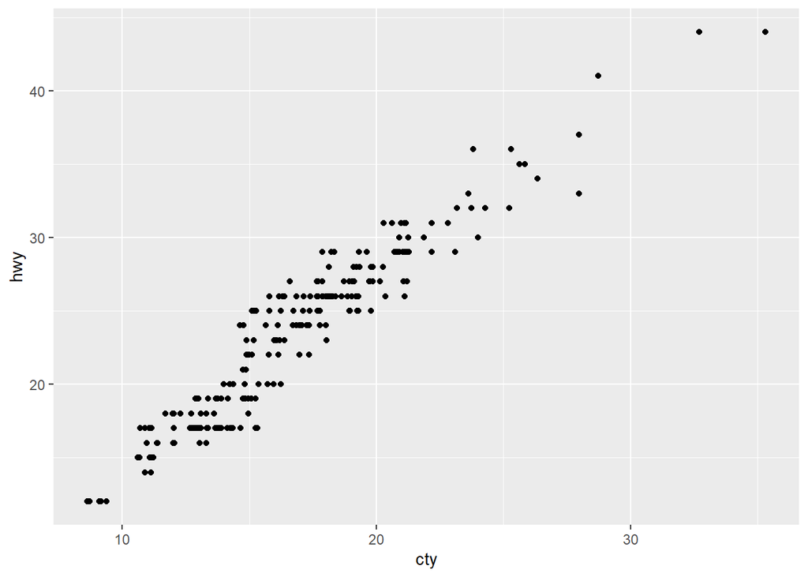

```r
ggplot(data = mpg, mapping = aes(x = cty, y = hwy)) +
  geom_jitter(height = 0)
```